# 5502 module 04 demonstration program

## File details

This program was written by Steve Simon on 2025-01-30 and is placed in the public domain. You can use this program any way you please.

There are four data files used in this program

- full-moon-er-admissions, [txt file](https://github.com/pmean/data/blob/main/files/full-moon-er-admissions.txt), [dictionary](https://github.com/pmean/data/blob/main/files/full-moon-er-admissions.yaml)
- tracking, [txt file](https://github.com/pmean/data/blob/main/files/tracking.txt), [dictionary](https://github.com/pmean/data/blob/main/files/tracking.yaml)
- exercise-programs, [SPSS file](https://github.com/pmean/data/blob/main/files/exercise-programs.sav), [dictionary](https://github.com/pmean/data/blob/main/files/exercise-programs.yaml)
- pulmonary, [csv file](https://github.com/pmean/data/blob/main/files/fev.csv), [dictionary](https://github.com/pmean/data/blob/main/files/fev.yaml)

```r
library(broom)
library(glue)
library(knitr)
library(tidyverse)
R.version.string
```

```
[1] "R version 4.5.0 (2025-04-11 ucrt)"
```

```r
Sys.Date()
```

```
[1] "2026-02-09"
```

## Intermediate files, er_admits

- er_admits0: 0riginal data from full-moon-er-admissions.txt
- er_admits1: re-order month and moon levels
- lm_null_model: null model for predicting admits
- lm_moon_model: model using moon to predict admits
- lm_moon_month_model: model using moon, month to predict admits
- ex: Original data from exercise.sav
- ex_1: Create factors for female and prog
- ex_2: Create indicator variables
- plot_05: Line plot for Exercise data
- plot_06: Alternative line plot for Exercise data
- pulmonary: Original data from fev.csv

# — Part 1, Review one factor analysis of variance

## Read the moon data

```r
er_admits0 <- read_tsv(
  file="../data/full-moon-er-admissions.txt",
  col_names=TRUE,
  col_types="ccn")

names(er_admits0) <- tolower(names(er_admits0))

glimpse(er_admits0)
```

```
Rows: 36
Columns: 3
$ month     <chr> "Aug", "Sep", "Oct", "Nov", "Dec", "Jan", "Feb", "Mar", "Apr…
$ moon      <chr> "Before", "Before", "Before", "Before", "Before", "Before", …
$ admission <dbl> 6.4, 7.1, 6.5, 8.6, 8.1, 10.4, 11.5, 13.8, 15.4, 15.7, 11.7,…
```

#### Comment on the code

It is optional, but I often like to convert my variable names to all lower case rather than having an initial capital letter. So “Moon” changes to “moon”, for example. Having variables as consistently all lower case makes things easier for me to remember when I switch from one dataset to another.

## Create factors

```r
month_list <- c(
  "Aug",
  "Sep",
  "Oct",
  "Nov",
  "Dec",
  "Jan",
  "Feb",
  "Mar",
  "Apr",
  "May",
  "Jun",
  "Jul")

phase_list <- c(
  "Before",
  "During",
  "After")

er_admits0 |>
  mutate(month=factor(month, levels=month_list)) |>
  mutate(moon=factor(moon, levels=phase_list)) -> er_admits1
```

#### Comment on the code

By default, when R encounters a string, it will use alphabetical order in arranging the display in graphs. You can change this option by using the factor function. Create a vector listing the string values in the order that you want them displayed and then use that vector as the levels argument inside the factor function.

## Descriptive statistics

```r
er_admits1 |>
    count(month) |>
    mutate(total=sum(n)) |>
    mutate(pct=round(100*n/total)) |>
      mutate(pct=glue("{pct}% ({n}/{total})")) |>
      select(-n, -total) -> month_table

month_table
```

```
# A tibble: 12 × 2
   month pct
   <fct> <glue>
 1 Aug   8% (3/36)
 2 Sep   8% (3/36)
 3 Oct   8% (3/36)
 4 Nov   8% (3/36)
 5 Dec   8% (3/36)
 6 Jan   8% (3/36)
 7 Feb   8% (3/36)
 8 Mar   8% (3/36)
 9 Apr   8% (3/36)
10 May   8% (3/36)
11 Jun   8% (3/36)
12 Jul   8% (3/36)
```

#### Interpretation of the output

There are twelve months, each representing 8% (1/12) of the data.

```r
er_admits1 |>
    count(moon) |>
    mutate(total=sum(n)) |>
    mutate(pct=round(100*n/total)) |>
      mutate(pct=glue("{pct}% ({n}/{total})")) |>
      select(-n, -total) -> moon_table

moon_table
```

```
# A tibble: 3 × 2
  moon   pct
  <fct>  <glue>
1 Before 33% (12/36)
2 During 33% (12/36)
3 After  33% (12/36)
```

#### Interpretation of the output

There are three phase times, each representing 33% (1/3) of the data.

```r
er_admits1 |>
  summarize(
    admission_mean=mean(admission),
    admission_sd=sd(admission),
    admission_min=min(admission),
    admission_max=max(admission)) -> admits_table

admits_table
```

```
# A tibble: 1 × 4
  admission_mean admission_sd admission_min admission_max
           <dbl>        <dbl>         <dbl>         <dbl>
1           11.9         4.23             5            25
```

#### Interpretation of the output

The average number of admissions is about 12 patients per day. There is a moderate amount of variation in the data.

## Lineplot

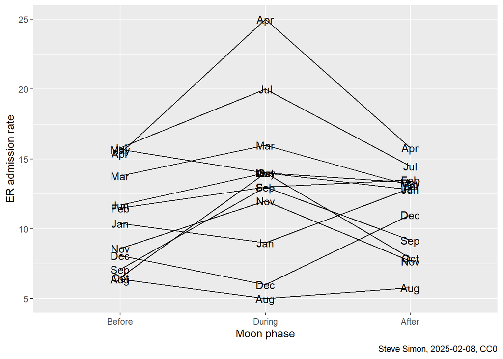

```r
er_admits1 |>
  ggplot() +
  aes(x=moon, y=admission) +
  geom_line(aes(group=month)) +
  geom_text(aes(label=month)) +
  labs(
    x="Moon phase",
    y="ER admission rate",
    caption="Steve Simon, 2025-02-08, CC0") -> admits_plot1

admits_plot1
```

#### Comment on the output

You have already used the [aes](https://ggplot2.tidyverse.org/reference/aes.html) function to define the x and y axes for various visualizations in ggplot. There are other applications of the aes function that can help control other features of your visualization.

The group argument in the aes function tells the geom_line function that you want a separate line for each month of the year. The label argument in the aes function tells the geom_text function to write the string value of month at each combination of x=moon and y=admission.

## Alternative lineplot

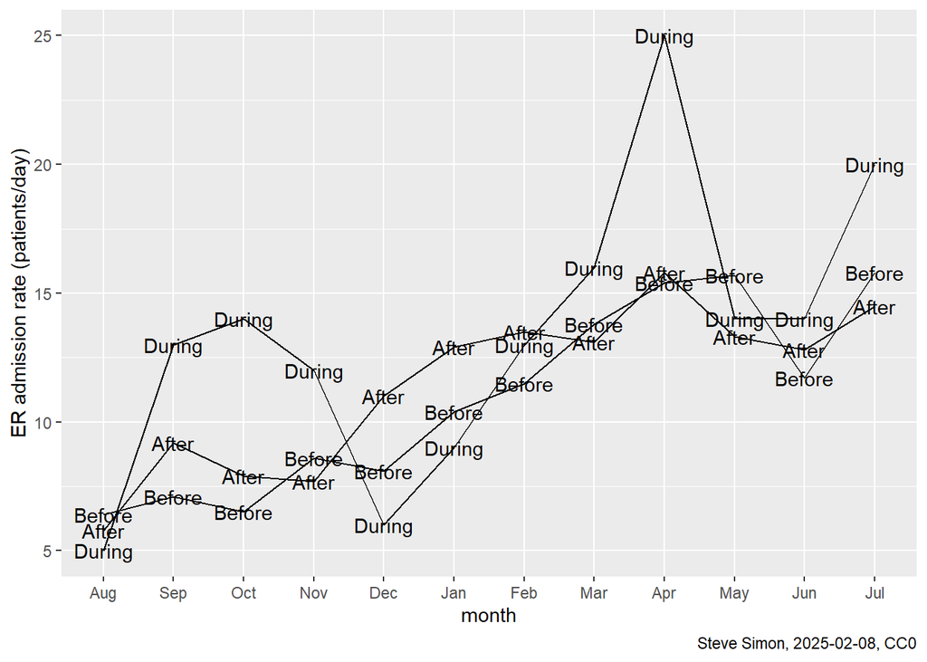

```r
er_admits1 |>
  ggplot() +
  aes(x=month, y=admission) +
  geom_line(aes(group=moon)) +
  geom_text(aes(label=moon)) +
  labs(
    y="ER admission rate (patients/day)",
    caption="Steve Simon, 2025-02-08, CC0") -> admits_plot2

admits_plot2
```

#### Comment on the code

By swapping the roles of Month and Moon inside the ggplot function, you get a different appearance. It is not always clear which way to draw the line graph. It usually helps for you to look at both approaches, but then display only the one that you think helps create the simplest interpretation of what is going on.

You don’t need a label for the x-axis in this plot because “month” is sufficiently descriptive.

Which graph do you like better? I tend to waver between the two.

## Mean Admission by Moon

```r
er_admits1 |>
  group_by(moon) |>
  summarize(
    Admission_mean=mean(admission),
    Admission_sd=sd(admission)) -> admits_by_moon_table

admits_by_moon_table
```

```
# A tibble: 3 × 3
  moon   Admission_mean Admission_sd
  <fct>           <dbl>        <dbl>
1 Before           10.9         3.62
2 During           13.4         5.50
3 After            11.5         3.11
```

#### Interpretation of the output

The average admission rate before a full moon is 11 patients per day. During a full moon the average rises by 2.5 patients per day. It falls back after a full moon but only by 2 patients per day.

## Fit three models

```r
lm_null_model <- lm(admission ~ 1, data=er_admits1)
lm_moon_model <- lm(admission ~ moon, data=er_admits1)
lm_moon_month_model <- lm(admission ~ moon + month, data=er_admits1)
```

## Single factor analysis of variance

```r
anova(lm_null_model, lm_moon_model) |>
  tidy() |>
  mutate(
    p.value =
      case_when(
        p.value >= 0.001 ~ glue("p = {round(p.value, 3)}"),
        p.value <  0.001 ~ "p < 0.001")) -> anova_moon_table

anova_moon_table
```

```
# A tibble: 2 × 7
  term             df.residual   rss    df sumsq statistic p.value
  <chr>                  <dbl> <dbl> <dbl> <dbl>     <dbl> <glue>
1 admission ~ 1             35  625.    NA  NA       NA    <NA>
2 admission ~ moon          33  583.     2  41.5      1.17 p = 0.322
```

## Parameter estimates

```r
tidy(lm_moon_model) |>
  mutate(
    p.value =
      case_when(
        p.value >= 0.001 ~ glue("p = {round(p.value, 3)}"),
        p.value <  0.001 ~ "p < 0.001")) -> estimates_moon_table

estimates_moon_table
```

```
# A tibble: 3 × 5
  term        estimate std.error statistic p.value
  <chr>          <dbl>     <dbl>     <dbl> <glue>
1 (Intercept)   10.9        1.21     8.99  p < 0.001
2 moonDuring     2.50       1.72     1.46  p = 0.155
3 moonAfter      0.542      1.72     0.316 p = 0.754
```

#### Comment on the code

Normally the reference category would be selected as the first alphabetically, but we used the factor function to place the strings in the order “Before”, “During”, and “After”. So the reference category is “Before”. You might prefer to use “During” as the reference category, which would be easy enough to achieve.

#### Interpretation of the output

Here are the parameter estimates. The intercept is the estimated average rate when the first and second indicator both equal zero. This is effectively the average rate for the reference category (before a full moon).

The first slope is the estimated average difference in rates when you increase the first indicator by one unit and hold the second indicator constant. This is effectively the average rate for the second group (during a full moon) minus the average rate for the reference group (before a full moon). When the days switch from before a full moon to during a full moon, the estimated average admission rate increases by about 2.5 patients/day.

The second slope is the estimated average difference in rates when you increase the second indicator by one unit and hold the first indicator constant. This is effectively the the average rate for the third group (after a full moon) minus the average rate for the reference group (before a full moon). When the days switch from before a full moon to after a full moon, the estimated average admission rate increases about half a patient per day.

# — Part 2, Two factor analysis of variance

## Parameter estimates

```r
tidy(lm_moon_month_model) |>
  mutate(
    p.value =
      case_when(
        p.value >= 0.001 ~ glue("p = {round(p.value, 3)}"),
        p.value <  0.001 ~ "p < 0.001")) -> estimates_moon_month_table

estimates_moon_month_table
```

```
# A tibble: 14 × 5
   term        estimate std.error statistic p.value
   <chr>          <dbl>     <dbl>     <dbl> <glue>
 1 (Intercept)    4.72      1.50      3.14  p = 0.005
 2 moonDuring     2.5       0.984     2.54  p = 0.019
 3 moonAfter      0.542     0.984     0.550 p = 0.588
 4 monthSep       4.03      1.97      2.05  p = 0.053
 5 monthOct       3.73      1.97      1.90  p = 0.071
 6 monthNov       3.70      1.97      1.88  p = 0.073
 7 monthDec       2.63      1.97      1.34  p = 0.195
 8 monthJan       5.03      1.97      2.56  p = 0.018
 9 monthFeb       6.93      1.97      3.52  p = 0.002
10 monthMar       8.57      1.97      4.35  p < 0.001
11 monthApr      13.0       1.97      6.61  p < 0.001
12 monthMay       8.60      1.97      4.37  p < 0.001
13 monthJun       7.10      1.97      3.61  p = 0.002
14 monthJul      11.0       1.97      5.61  p < 0.001
```

#### Interpretation of the output

These are the parameter estimates for the two factor analysis of variance. The reference categories are “Before” and “Aug”.

The intercept represents the average admission rate before a full moon when the month is August. The two terms associated with moon show how much changes there is from before a full moon to during a full moon and from before a full moon to after a full moon, respectively. The remaining parameter estimates show how much each month differs from the first month (August).

## Anova table, 1

```r
anova(lm_null_model, lm_moon_month_model) |>
  tidy() |>
  mutate(
    p.value =
      case_when(
        p.value >= 0.001 ~ glue("p = {round(p.value, 3)}"),
        p.value <  0.001 ~ "p < 0.001")) -> anova_moon_month_table

anova_moon_month_table
```

```
# A tibble: 2 × 7
  term                     df.residual   rss    df sumsq statistic p.value
  <chr>                          <dbl> <dbl> <dbl> <dbl>     <dbl> <glue>
1 admission ~ 1                     35  625.    NA   NA      NA    <NA>
2 admission ~ moon + month          22  128.    13  497.      6.58 p < 0.001
```

#### Interpretation of the output

There is a statistically significant improvement in prediction when you use Month and Moon to predict admission rates compared to a null model.

## Anova table, 2

```r
anova(lm_moon_model, lm_moon_month_model) |>
  tidy() |>
  mutate(
    p.value =
      case_when(
        p.value >= 0.001 ~ glue("p = {round(p.value, 3)}"),
        p.value <  0.001 ~ "p < 0.001")) -> partial_month_table

partial_month_table
```

```
# A tibble: 2 × 7
  term                     df.residual   rss    df sumsq statistic p.value
  <chr>                          <dbl> <dbl> <dbl> <dbl>     <dbl> <glue>
1 admission ~ moon                  33  583.    NA   NA      NA    <NA>
2 admission ~ moon + month          22  128.    11  456.      7.13 p < 0.001
```

#### Interpretation of the output

There is a statistically significant improvement in prediction when you use Month and Moon to predict admission rates compared to a model with just Moon.

## Comparison of r-squared values

```r
glance(lm_null_model) |>
    bind_rows(glance(lm_moon_model)) |>
    bind_rows(glance(lm_moon_month_model)) |>
    mutate(model=c("Null", "Moon", "Moon Month")) |>
    select(model, r.squared, deviance) -> admits_rsquared_table

admits_rsquared_table
```

```
# A tibble: 3 × 3
  model      r.squared deviance
  <chr>          <dbl>    <dbl>
1 Null          0          625.
2 Moon          0.0664     583.
3 Moon Month    0.795      128.
```

#### Interpretation of the output

The first factor, moon, only accounts for 7% of the variation in admission rates. Adding a second factor improves the model substantially.

## Tukey post hoc test

```r
lm_moon_month_model |>
  aov() |>
  TukeyHSD(ordered=TRUE, which="moon") |>
  tidy() |>
  mutate(
    adj.p.value =
      case_when(
        adj.p.value >= 0.001 ~ as.character(round(adj.p.value, 3),
        adj.p.value <  0.001 ~ "< 0.001"))) -> tukey_moon_table

tukey_moon_table
```

```
# A tibble: 3 × 7
  term  contrast      null.value estimate conf.low conf.high adj.p.value
  <chr> <chr>              <dbl>    <dbl>    <dbl>     <dbl> <chr>
1 moon  After-Before           0    0.542  -1.93        3.01 0.847
2 moon  During-Before          0    2.50    0.0280      4.97 0.047
3 moon  During-After           0    1.96   -0.514       4.43 0.138
```

#### Comment on the code

With two factors, you should provide information to the TukeyHSD function about the pairwise comparison(s) that you are interested in. Use the which argument to do this. If you leave the which argument out, the TukeyHSD function will do all pairwise comparisons among the three moon phases and all pairwise comparisons among the 12 months. The real interest in this study is how admission rates change by the phase of the moon and you only included the month in the model to remove some of the variations over time.

#### Interpretation of the output

There is no statistically significant difference between the average admission rate before and after a full moon. There is a statistically difference between the average admission rate before and during a full moon. This, however, is a borderline difference. The adjusted p-values is close to 0.05 and the lower limit of the confidence interval comes within kissing distance of zero. There is no statistically significant difference between the average admission rate during a full moon and after a full moon. This, however, is also a borderline result. The confidence interval does include zero, but just barely. Perhaps the only safe interpretation here is that you need more data.

# — Part 3, Checking assumptions

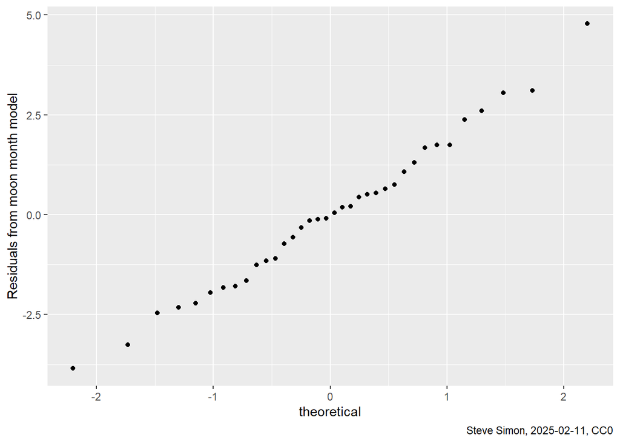

```r
augment_moon_month <- augment(lm_moon_month_model)

augment_moon_month |>
    ggplot() +
    aes(sample=.resid) +
    stat_qq() +
  labs(
    y="Residuals from moon month model",
    caption="Steve Simon, 2025-02-11, CC0") -> qq_residuals_plot

qq_residuals_plot
```

#### Interpretation of the output

There is no evidence of non-normality.

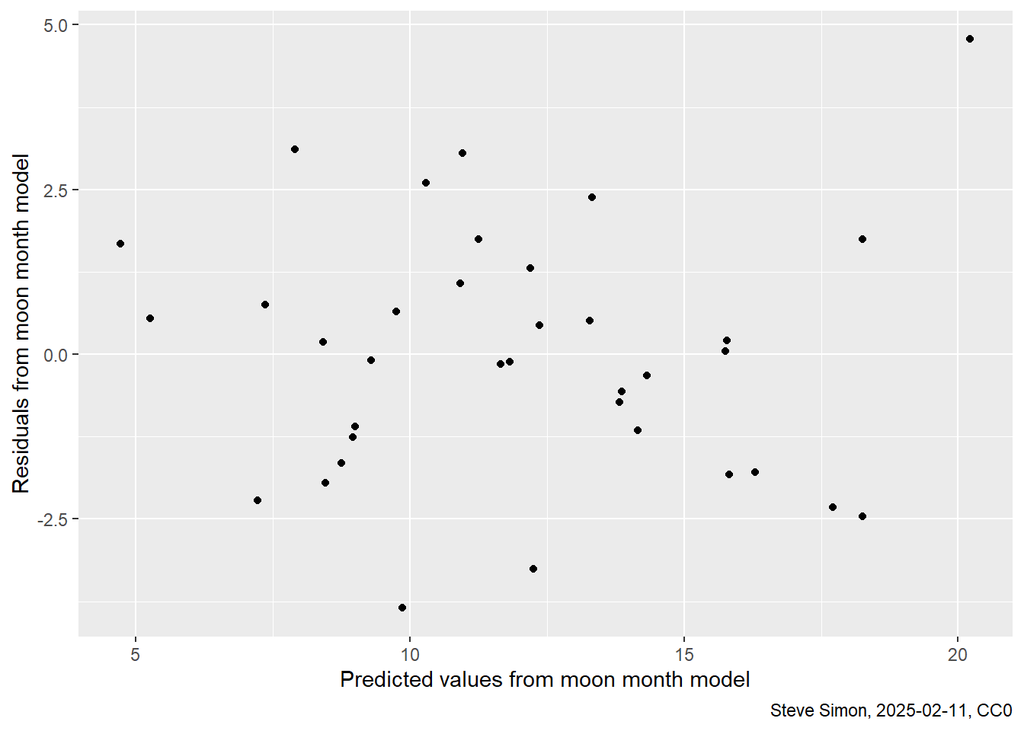

```r
augment_moon_month |>
    ggplot() +
    aes(x=.fitted, y=.resid) +
    geom_point() +
  labs(
    x="Predicted values from moon month model",
    y="Residuals from moon month model",
    caption="Steve Simon, 2025-02-11, CC0") -> predicted_residuals_plot

predicted_residuals_plot
```

# — Part 4, Interactions in multi-factor analysis of variance

## Read tracking data

```r
tracking0 <- read_tsv(
  file="../data/tracking.txt",
  col_types="cncnnnn",
  col_names=TRUE)
names(tracking0) <- tolower(names(tracking0))

glimpse(tracking0)
```

```
Rows: 108
Columns: 7
$ sex    <chr> "M", "M", "M", "M", "M", "M", "M", "M", "M", "M", "F", "F", "F"…
$ age    <dbl> 31, 30, 30, 27, 30, 28, 34, 28, 28, 33, 17, 24, 7, 11, 38, 45, …
$ shape  <chr> "Box", "Box", "Box", "Box", "Box", "Box", "Box", "Box", "Box", …
$ trial1 <dbl> 2.68, 7.09, 6.05, 4.35, 4.08, 8.22, 4.51, 7.36, 3.34, 7.19, 2.1…
$ trial2 <dbl> 4.14, 8.55, 6.25, 6.50, 6.00, 8.01, 4.35, 6.63, 5.24, 7.96, 5.9…
$ trial3 <dbl> 7.22, 8.79, 7.04, 5.17, 6.82, 8.18, 4.87, 7.99, 4.27, 7.18, 4.5…
$ trial4 <dbl> 8.00, 9.68, 7.80, 6.50, 6.68, 8.45, 6.38, 7.26, 6.29, 7.99, 3.8…
```

https://gksmyth.github.io/ozdasl/general/tracking.html https://gksmyth.github.io/ozdasl/general/tracking.txt

## Create Child variable

```r
tracking0 |>
  mutate(child = case_when(
    age <= 18 ~ "yes",
    age > 18 ~ "no")) -> tracking1
```

## Descriptive statistics for sex

```r
tracking1 |>
  count(sex) |>
  mutate(total=sum(n)) |>
  mutate(pct=round(100*n/total)) |>
  mutate(pct=glue("{pct}% ({n}/{total})")) |>
  select(-n, -total)
```

```
# A tibble: 2 × 2
  sex   pct
  <chr> <glue>
1 F     38% (41/108)
2 M     62% (67/108)
```

#### Interpretatipon of the output

Males comprise 62% of the sample

## Descriptive statistics for child

```r
tracking1 |>
  count(child) |>
  mutate(total=sum(n)) |>
  mutate(pct=round(100*n/total)) |>
  mutate(pct=glue("{pct}% ({n}/{total})")) |>
  select(-n, -total)
```

```
# A tibble: 2 × 2
  child pct
  <chr> <glue>
1 no    44% (48/108)
2 yes   56% (60/108)
```

#### Interpretation of the output

Children (18 and younger) comprise 56% of the sample.

## Descriptive statistics for shape

```r
tracking1 |>
  count(shape) |>
  mutate(total=sum(n)) |>
  mutate(pct=round(100*n/total)) |>
  mutate(pct=glue("{pct}% ({n}/{total})")) |>
  select(-n, -total)
```

```
# A tibble: 2 × 2
  shape  pct
  <chr>  <glue>
1 Box    65% (70/108)
2 Circle 35% (38/108)
```

## Descriptive statistics for trial4

```r
tracking1 |>
  summarize(
    trial4_mean=mean(trial4),
    trial4_sd=sd(trial4),
    trial4_min=min(trial4),
    trial4_max=max(trial4))
```

```
# A tibble: 1 × 4
  trial4_mean trial4_sd trial4_min trial4_max
        <dbl>     <dbl>      <dbl>      <dbl>
1        4.13      2.73        0.1       11.4
```

#### Interpretation of the output

The tracking task lasted for 15 seconds, so the average time is quite low. There is a wide range of variation, with one subject tracking for more than 11 seconds out of 15.

## Boxplots

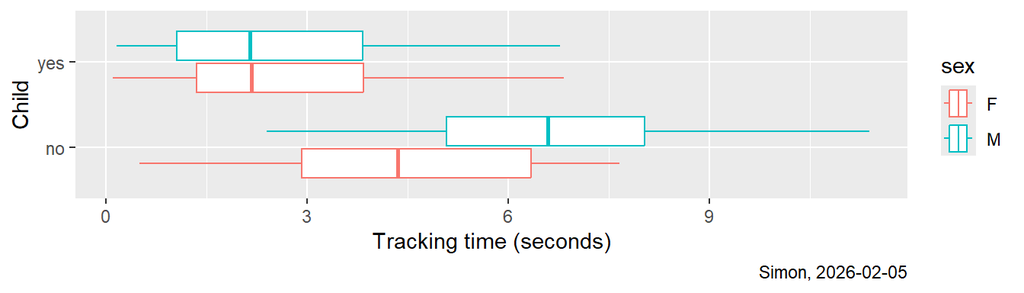

```r
tracking1 |>
  ggplot() +
  aes(
    x=trial4,
    y=child,
    color=sex) +
  geom_boxplot() +
  labs(
    x="Tracking time (seconds)",
    y="Child",
    caption="Simon, 2026-02-05")
```

# — Part 5, Interactions in analysis of covariance

```r
library(haven)

ex <- read_sas(
  data_file="../data/exercise.sas7bdat")
glimpse(ex)
```

```
Rows: 900
Columns: 8
$ prog      <dbl> 1, 1, 1, 1, 1, 1, 1, 1, 1, 1, 1, 1, 1, 1, 1, 1, 1, 1, 1, 1, …
$ i         <dbl> 1, 2, 3, 4, 5, 6, 7, 8, 9, 10, 11, 12, 13, 14, 15, 16, 17, 1…
$ hours     <dbl> 1.836704, 2.389360, 2.362117, 2.520866, 1.889828, 2.367162, …
$ female    <dbl> 0, 0, 0, 0, 0, 0, 0, 0, 0, 0, 0, 0, 0, 0, 0, 0, 0, 0, 0, 0, …
$ effort    <dbl> 37.71218, 26.72401, 36.31657, 20.70048, 24.72712, 33.66948, …
$ loss      <dbl> 18.022263, 10.186416, 19.747276, 1.883600, 14.242589, 19.694…
$ satiscont <dbl> 3.8426090, 4.8501397, 5.8883549, 6.3851246, 4.2493271, 4.226…
$ satisfied <dbl> 0, 0, 0, 0, 0, 0, 0, 0, 0, 1, 0, 0, 0, 0, 1, 0, 1, 0, 1, 0, …
```

## Add factors

```r
lab1 <- c("Reading", "Jogging", "Swimming")
lab2 <- c("Male", "Female")

ex |>
  mutate(prog=factor(prog, levels=c(3, 1, 2), labels=lab1)) |>
  mutate(gender=factor(female, levels=0:1, labels=lab2)) -> ex_1
```

#### Comment on the code

Notice that the levels for prog are specified in an alternative order. This is done to insure that the control group (reading) is the reference level in all statistical models.

I also used gender rather than female for the factor name. This is something I only noticed after working with this dataset for a while. Certain parts of the output would be labelled as femaleFemale or femaleMale and I thought it would look nicer as genderFemale and genderMale. Normally I try to avoid making too many changes to the names of variables. It makes it easier to refer back to the original data dictionary.

## Descriptive statistics

```r
ex_1 |>
    count(prog) |>
    mutate(total=sum(n)) |>
    mutate(pct=round(100*n/total)) |>
  mutate(pct=glue("{pct}% ({n}/{total})")) |>
  select(-n, -total)
```

```
# A tibble: 3 × 2
  prog     pct
  <fct>    <glue>
1 Reading  33% (300/900)
2 Jogging  33% (300/900)
3 Swimming 33% (300/900)
```

#### Interpretation of the output

Exactly one third of the patients are in each of the three exercise programs.

```r
ex_1 |>
    count(i) |>
    mutate(total=sum(n)) |>
    mutate(pct=round(100*n/total, 2)) |>
  mutate(pct=glue("{pct}% ({n}/{total})")) |>
  select(-n, -total)
```

```
# A tibble: 300 × 2
       i pct
   <dbl> <glue>
 1     1 0.33% (3/900)
 2     2 0.33% (3/900)
 3     3 0.33% (3/900)
 4     4 0.33% (3/900)
 5     5 0.33% (3/900)
 6     6 0.33% (3/900)
 7     7 0.33% (3/900)
 8     8 0.33% (3/900)
 9     9 0.33% (3/900)
10    10 0.33% (3/900)
# ℹ 290 more rows
```

#### Interpretation of the output

This table doesn’t really help so much and I should probably have deleted this program chunk.

```r
ex_1 |>
  summarize(
    hours_mean=mean(hours),
    hours_sd=sd(hours),
    hours_min=min(hours),
    hours_max=max(hours))
```

```
# A tibble: 1 × 4
  hours_mean hours_sd hours_min hours_max
       <dbl>    <dbl>     <dbl>     <dbl>
1       2.00    0.495     0.175      4.07
```

#### Interpretation of the output

The average patient exercised for 2 hours per week. There is a lot of variation, with at least one patient only exercising for ten minutes.

```r
ex_1 |>
    count(gender) |>
    mutate(total=sum(n)) |>
    mutate(pct=round(100*n/total)) |>
  mutate(pct=glue("{pct}% ({n}/{total})")) |>
  select(-n, -total)
```

```
# A tibble: 2 × 2
  gender pct
  <fct>  <glue>
1 Male   50% (450/900)
2 Female 50% (450/900)
```

#### Interpretation of the output

There are equal numbers of men and women in the study.

#### Interpretation of the output

```r
ex_1 |>
  summarize(
    effort_mean=mean(effort),
    effort_sd=sd(effort),
    effort_min=min(effort),
    effort_max=max(effort))
```

```
# A tibble: 1 × 4
  effort_mean effort_sd effort_min effort_max
        <dbl>     <dbl>      <dbl>      <dbl>
1        29.7      5.14       12.9       44.1
```

#### Interpretation of the output

Effort is measured on a scale from 0 to 50. The average effort was 30, roughly in the middle of this range. There is only a moderate amount of variation, with no one really very close to the low extreme of 0 or the high extreme of 50.

```r
ex_1 |>
  summarize(
    loss_mean=mean(loss),
    loss_sd=sd(loss),
    loss_min=min(loss),
    loss_max=max(loss))
```

```
# A tibble: 1 × 4
  loss_mean loss_sd loss_min loss_max
      <dbl>   <dbl>    <dbl>    <dbl>
1      10.0    14.1    -17.1     54.2
```

## Interaction between prog and gender on loss

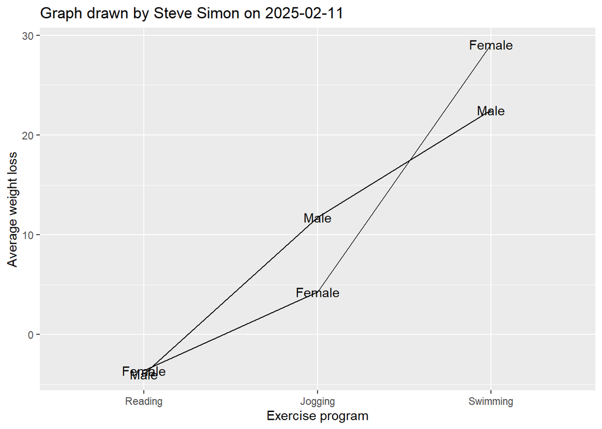

```r
ex_1 |>
  group_by(prog, gender) |>
  summarize(
    loss_mean=mean(loss)) |>
  ggplot() +
  aes(x=prog, y=loss_mean) +
  geom_line(aes(group=gender)) +
  geom_text(aes(label=gender)) +
  ggtitle("Graph drawn by Steve Simon on 2025-02-11") +
  xlab("Exercise program") +
  ylab("Average weight loss") -> plot_05
plot_05
```

#### Comment on the code

There is a warning message associated with this program chunk. It does not affect the validity of the output. I explain some of the details behind this warning in a webpage to be published soon.

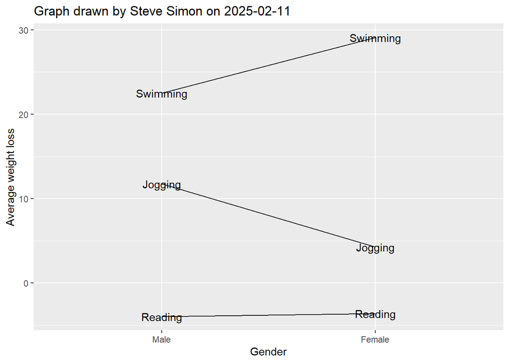

```r
ex_1 |>
  group_by(prog, gender) |>
  summarize(
    loss_mean=mean(loss)) |>
  ggplot() +
  aes(x=gender, y=loss_mean) +
  geom_line(aes(group=prog)) +
  geom_text(aes(label=prog)) +
  ggtitle("Graph drawn by Steve Simon on 2025-02-11") +
  xlab("Gender") +
  ylab("Average weight loss") -> plot_06
plot_06
```

#### Interpretation of the output

# — Part 6, Interations in multiple linear regression

## Save everything

```r
save(
  er_admits0,
  er_admits1,

  month_table,
  moon_table,
  admits_table,

  admits_plot1,
  admits_plot2,

  admits_by_moon_table,

  lm_null_model,
  lm_moon_model,
  lm_moon_month_model,

  anova_moon_table,
  estimates_moon_table,
  estimates_moon_month_table,
  admits_rsquared_table,

  qq_residuals_plot,
  predicted_residuals_plot,

  tracking0,
  tracking1,

  file="../data/module04.RData")
```